# Linear Regression

18BCE1104 - Ankita Duraphe

04/02/2021

### Kindly note: All the three tasks assigned for EDA Lab Exercise 1 are done in this one R Markdown

### Regression Analysis

Consider the following 5 training examples: X = [2 3 4 5 6], Y = [12.8978, 17.7586, 23.3192, 28.3129, 32.1351] We want to learn a function f(x) of the form f(x) = a(x) + b which is parametrized by (a, b). Using squared error as the loss function, which of the following parameters would you like to use to model this function.

Create a dataframe for the given data

```r
data <- data.frame(x = c(2, 3, 4, 5, 6), y = c(12.8978, 17.7586, 23.3192, 28.3129, 32.1351))
data
```

```
##   x       y
## 1 2 12.8978
## 2 3 17.7586
## 3 4 23.3192
## 4 5 28.3129
## 5 6 32.1351
```

View the dataset

```r
head(data)
```

```
##   x       y
## 1 2 12.8978
## 2 3 17.7586
## 3 4 23.3192
## 4 5 28.3129
## 5 6 32.1351
```

Number of rows and columns in the dataset

```r
nrow(data)
```

```
## [1] 5
```

```r
ncol(data)
```

```
## [1] 2
```

```r
summary(data)
```

```
##        x           y
##  Min.   :2   Min.   :12.90
##  1st Qu.:3   1st Qu.:17.76
##  Median :4   Median :23.32
##  Mean   :4   Mean   :22.88
##  3rd Qu.:5   3rd Qu.:28.31
##  Max.   :6   Max.   :32.14
```

Check missing values

```r
is.na(mtcars)
```

[output not shown]

[output cut: 11 more lines]

[output not shown]

Plot

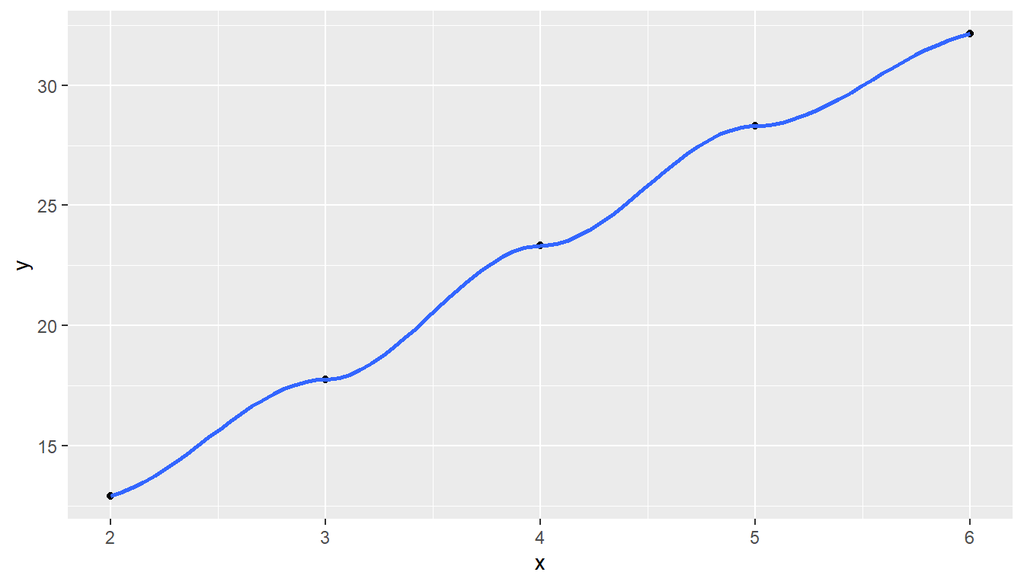

```r
library(ggplot2)
ggplot(data, aes(x = x, y = y)) +
  geom_point() +
  stat_smooth()
```

Autocorrelation

```r
cor(data$y, data$x)
```

```
## [1] 0.9982246
```

Applying Linear Regression Model

```r
fit <- lm(y ~ x, data)
```

Checking Summary after applying Linear Regression to the Model

```r
model <- lm(y ~ x, data = data)
model
```

```
##
## Call:
## lm(formula = y ~ x, data = data)
##
## Coefficients:
## (Intercept)            x
##       3.273        4.903
```

```r
summary(model)
```

```
##
## Call:
## lm(formula = y ~ x, data = data)
##
## Residuals:
##       1       2       3       4       5
## -0.1811 -0.2232  0.4345  0.5253 -0.5554
##
## Coefficients:
##             Estimate Std. Error t value Pr(>|t|)
## (Intercept)   3.2732     0.7166   4.568   0.0197 *
## x             4.9029     0.1689  29.028 8.98e-05 ***
## ---
## Signif. codes:  0 '***' 0.001 '**' 0.01 '*' 0.05 '.' 0.1 ' ' 1
##
## Residual standard error: 0.5341 on 3 degrees of freedom
## Multiple R-squared:  0.9965, Adjusted R-squared:  0.9953
## F-statistic: 842.6 on 1 and 3 DF,  p-value: 8.977e-05
```

Visualization

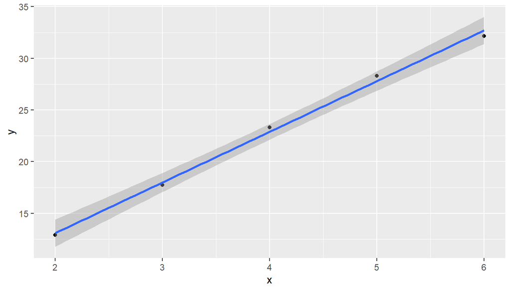

```r
ggplot(data, aes(x, y)) +
  geom_point() +
  stat_smooth(method = lm)
```

Plotting multiple graphs

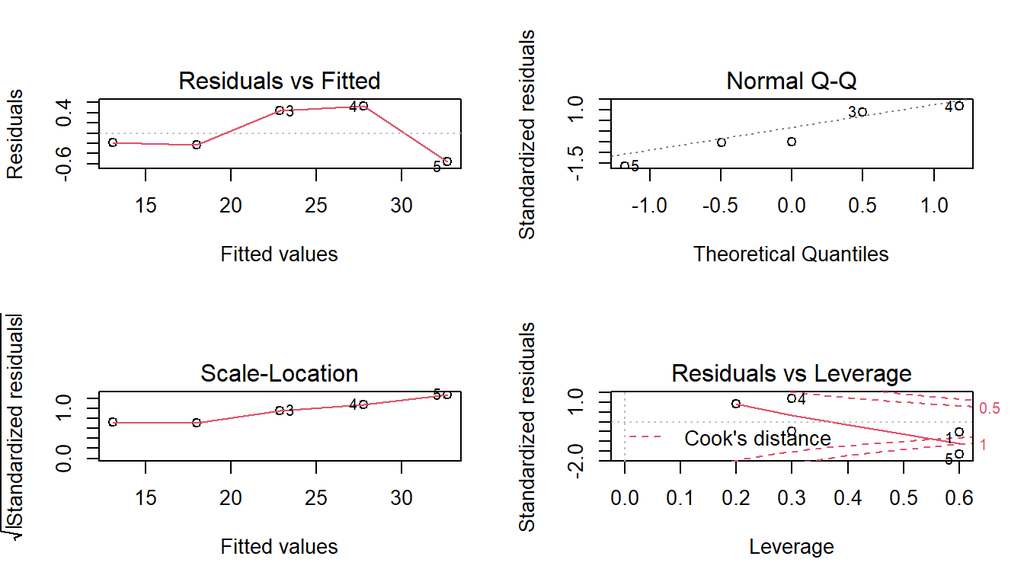

```r
par(mfrow=c(2,2))
plot((fit))
```

### Linear Regression on Age and Height

Load the required libraries

```r
library(ggpubr)
library(ggplot2)
library(readxl)
```

Upload the data

```r
ageandheight = read_excel("ageandheight.xls")
```

View the dataset

```r
View(ageandheight)
```

Regression - components: 1. independence of observation / autocorrelation

```r
cor(ageandheight$age, ageandheight$height)
```

```
## [1] 0.9943661
```

Regression - components: 2. normality / histogram

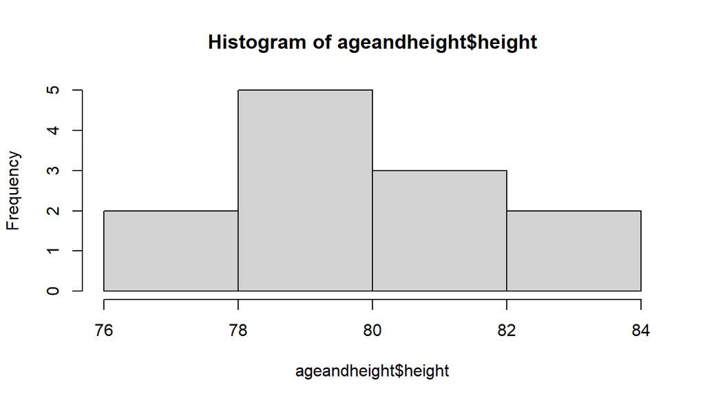

```r
hist(ageandheight$height)
```

Regression - components: 3.linearity

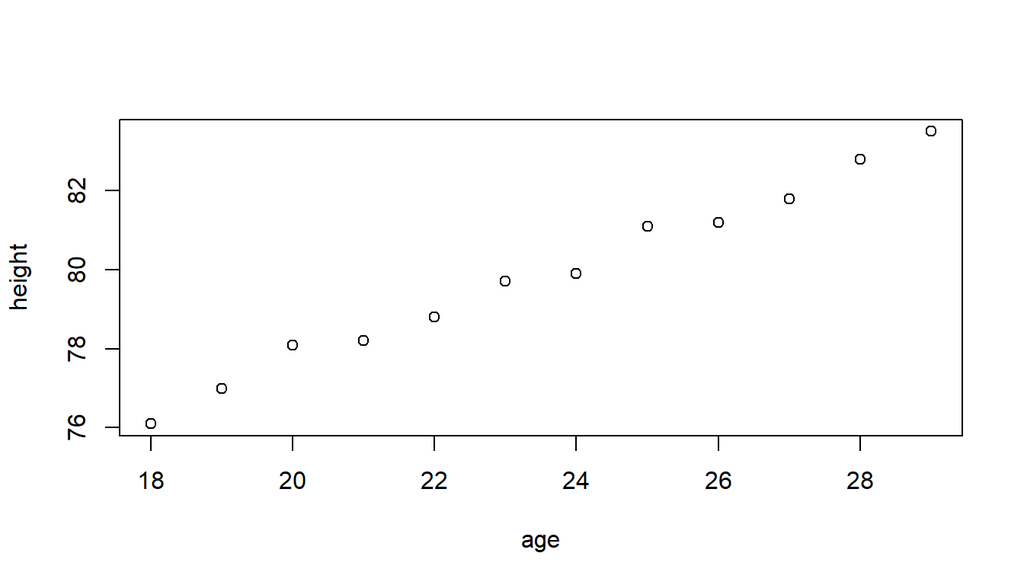

```r
plot(height~age, data = ageandheight)
```

Regression - components: 4.Homoscedasticity / homogeneity of variance

```r
lmHeight = lm(height~age, data = ageandheight)
```

for residual plots

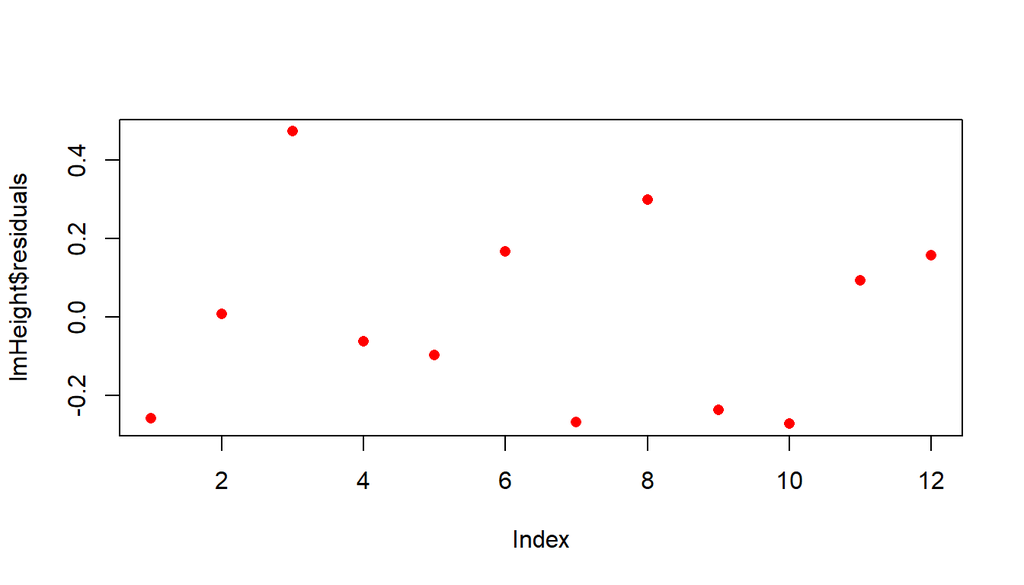

```r
plot(lmHeight$residuals, pch = 16, col = "red")
```

Review the results

```r
summary(lmHeight)
```

```
##
## Call:
## lm(formula = height ~ age, data = ageandheight)
##
## Residuals:
##      Min       1Q   Median       3Q      Max
## -0.27238 -0.24248 -0.02762  0.16014  0.47238
##
## Coefficients:
##             Estimate Std. Error t value Pr(>|t|)
## (Intercept)  64.9283     0.5084  127.71  < 2e-16 ***
## age           0.6350     0.0214   29.66 4.43e-11 ***
## ---
## Signif. codes:  0 '***' 0.001 '**' 0.01 '*' 0.05 '.' 0.1 ' ' 1
##
## Residual standard error: 0.256 on 10 degrees of freedom
## Multiple R-squared:  0.9888, Adjusted R-squared:  0.9876
## F-statistic:   880 on 1 and 10 DF,  p-value: 4.428e-11
```

Regression - components: 4.Homoscedasticity / homogeneity of variance

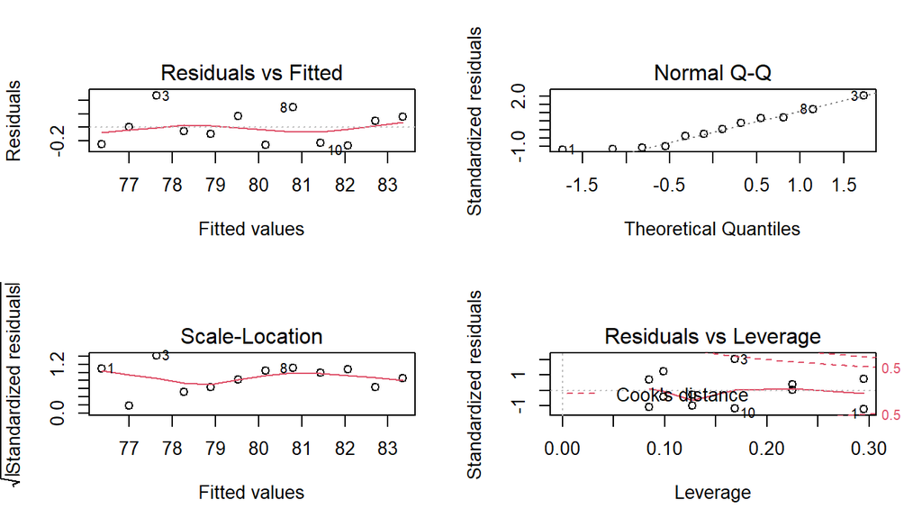

```r
par(mfrow=c(2,2))
plot(lmHeight)
```

To go back to plotting one graph in the entire window

```r
par(mfrow=c(1,1))
```

plot the data points on graph

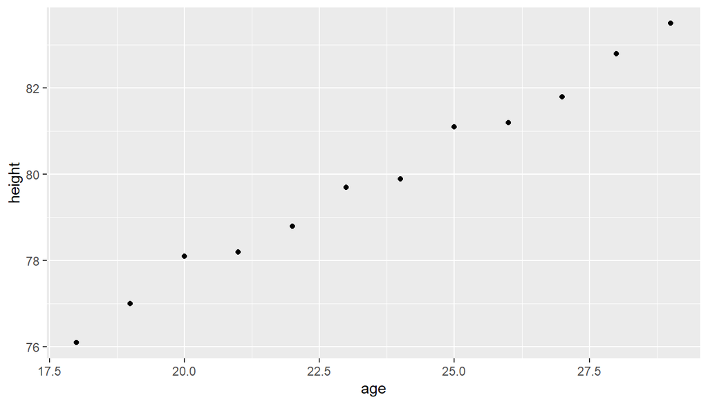

```r
lmHeight.graph = ggplot(ageandheight, aes(x=age,y=height))+ geom_point()
lmHeight.graph
```

Add the linear regression line to the plotted data

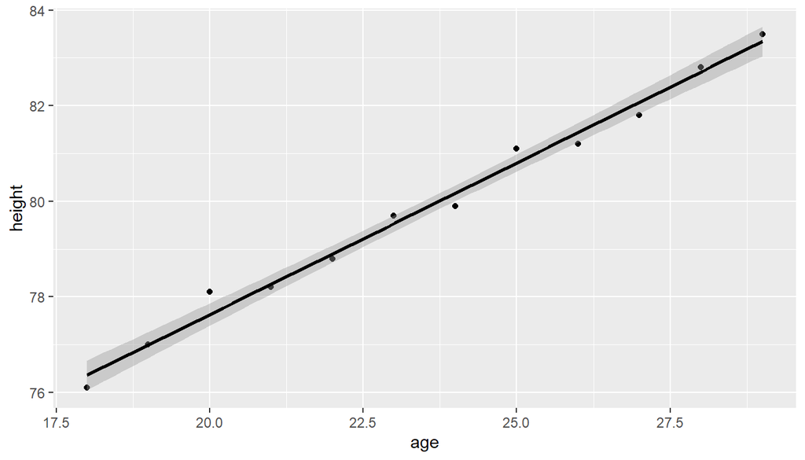

```r
lmHeight.graph = lmHeight.graph + geom_smooth(method ="lm", col="black")
lmHeight.graph
```

Add the equation for the regression line

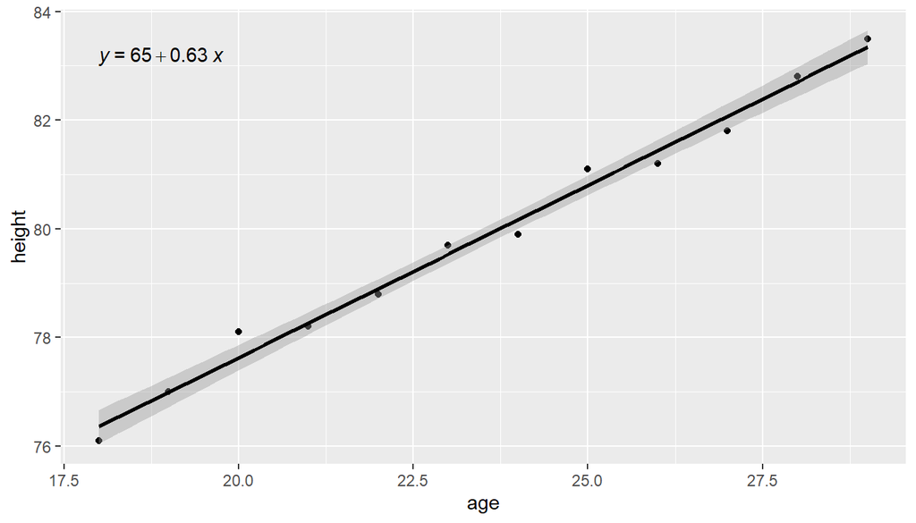

```r
lmHeight.graph = lmHeight.graph + stat_regline_equation()
lmHeight.graph
```

Make the graph ready for publication

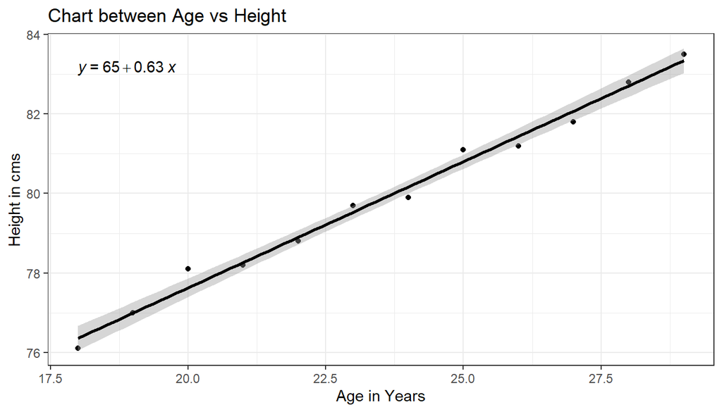

```r
lmHeight.graph + theme_bw() + labs(title = "Chart between Age vs Height", x = "Age in Years", y = "Height in cms")
```

When a regression takes into account two or more predictors to create the linear regression, it’s called multiple linear regression. Height = a + Age × b1 + (Number of Siblings} × b2 Create a linear regression with two variables

```r
lmHeight2 = lm(height~age + no_siblings, data = ageandheight)
```

for residual plots

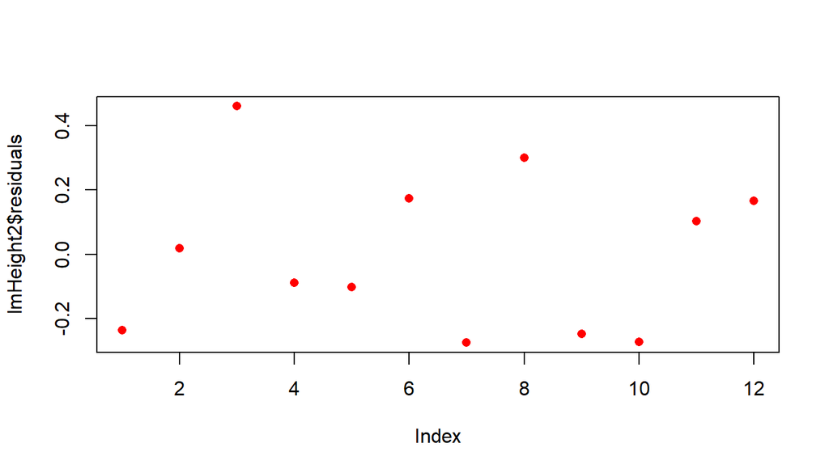

```r
plot(lmHeight2$residuals, pch = 16, col = "red")
```

Review the results

```r
summary(lmHeight2)
```

```
##
## Call:
## lm(formula = height ~ age + no_siblings, data = ageandheight)
##
## Residuals:
##     Min      1Q  Median      3Q     Max
## -0.2745 -0.2379 -0.0348  0.1676  0.4597
##
## Coefficients:
##             Estimate Std. Error t value Pr(>|t|)
## (Intercept) 64.87033    0.65120  99.617 5.25e-15 ***
## age          0.63631    0.02411  26.392 7.78e-10 ***
## no_siblings  0.01096    0.07010   0.156    0.879
## ---
## Signif. codes:  0 '***' 0.001 '**' 0.01 '*' 0.05 '.' 0.1 ' ' 1
##
## Residual standard error: 0.2694 on 9 degrees of freedom
## Multiple R-squared:  0.9888, Adjusted R-squared:  0.9863
## F-statistic: 397.1 on 2 and 9 DF,  p-value: 1.669e-09
```

Detect Influential Points.

```r
ageandheight[2, 2] = 7.7
head(ageandheight)
```

```
## # A tibble: 6 x 3
##     age height no_siblings
##   <dbl>  <dbl>       <dbl>
## 1    18   76.1           1
## 2    19    7.7           2
## 3    20   78.1           4
## 4    21   78.2           5
## 5    22   78.8           3
## 6    23   79.7           2
```

regression with outliers

```r
lmHeight3 = lm(height~age, data = ageandheight)
summary(lmHeight3)
```

```
##
## Call:
## lm(formula = height ~ age, data = ageandheight)
##
## Residuals:
##     Min      1Q  Median      3Q     Max
## -53.704  -2.584   3.609   9.503  17.512
##
## Coefficients:
##             Estimate Std. Error t value Pr(>|t|)
## (Intercept)    7.905     38.319   0.206    0.841
## age            2.816      1.613   1.745    0.112
##
## Residual standard error: 19.29 on 10 degrees of freedom
## Multiple R-squared:  0.2335, Adjusted R-squared:  0.1568
## F-statistic: 3.046 on 1 and 10 DF,  p-value: 0.1115
```

Plot the Cooks Distances

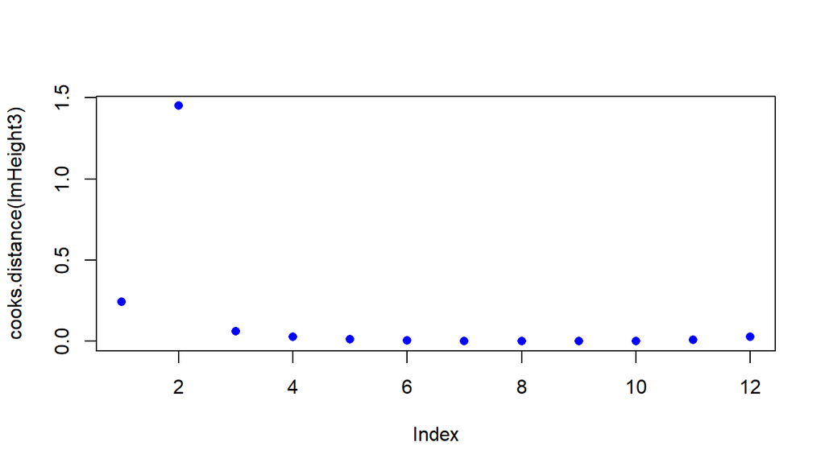

```r
plot(cooks.distance(lmHeight3), pch = 16, col = "blue")
```

### Linear Regression on mtcars

Load the required libraries

```r
library(ggpubr)
library(ggplot2)
```

sorting examples using mtcars dataset

```r
attach(mtcars)
View(mtcars)
```

Pre-processing: Converting “am” into a categorical variable by assigning AT(Automatic Transmission) = 0, MT(Manual Transmission) = 1

```r
mtData<-mtcars
mtData$am <- as.factor(mtData$am)
levels(mtData$am) <-c("AT", "MT")
```

Exploratory Analysis

1. Histogram of Mpg

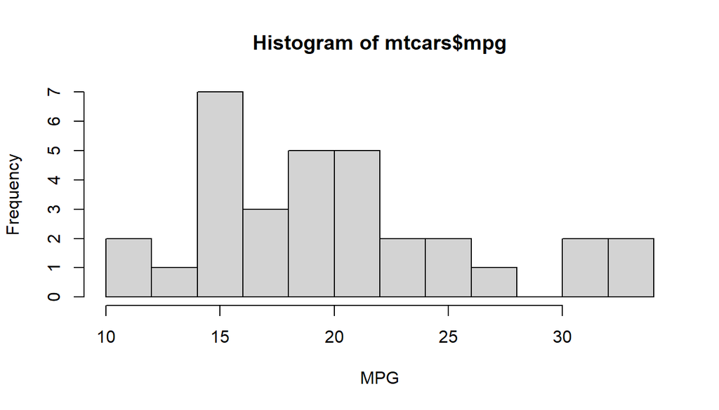

```r
hist(mtcars$mpg,breaks = 10,xlab="MPG")
```

2. Boxplot of mpg and am

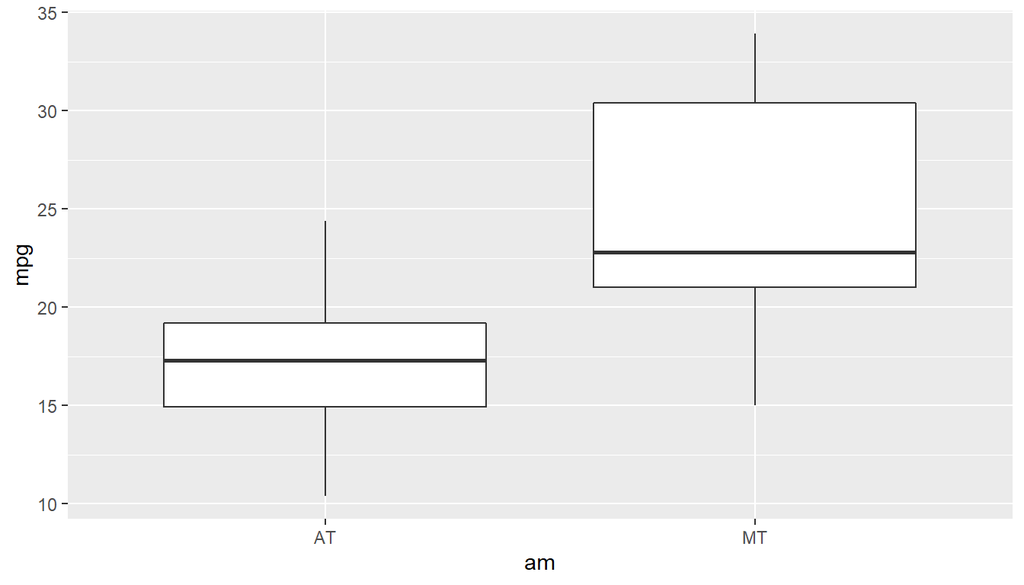

```r
library(ggplot2)
library(caret)
ggplot(mtData, aes(x=am, y=mpg)) + geom_boxplot()
```

Statistical Analysis

```r
set.seed(12345)
t.test(mtData$mpg~mtData$am)
```

```
##
##  Welch Two Sample t-test
##
## data:  mtData$mpg by mtData$am
## t = -3.7671, df = 18.332, p-value = 0.001374
## alternative hypothesis: true difference in means is not equal to 0
## 95 percent confidence interval:
##  -11.280194  -3.209684
## sample estimates:
## mean in group AT mean in group MT
##         17.14737         24.39231
```

Model Building

```r
fit<-lm(mpg~am,data=mtData)
summary(fit)
```

```
##
## Call:
## lm(formula = mpg ~ am, data = mtData)
##
## Residuals:
##     Min      1Q  Median      3Q     Max
## -9.3923 -3.0923 -0.2974  3.2439  9.5077
##
## Coefficients:
##             Estimate Std. Error t value Pr(>|t|)
## (Intercept)   17.147      1.125  15.247 1.13e-15 ***
## amMT           7.245      1.764   4.106 0.000285 ***
## ---
## Signif. codes:  0 '***' 0.001 '**' 0.01 '*' 0.05 '.' 0.1 ' ' 1
##
## Residual standard error: 4.902 on 30 degrees of freedom
## Multiple R-squared:  0.3598, Adjusted R-squared:  0.3385
## F-statistic: 16.86 on 1 and 30 DF,  p-value: 0.000285
```

```r
fit_all<-lm(mpg~.,data=mtData)
```

Residual Error Plot

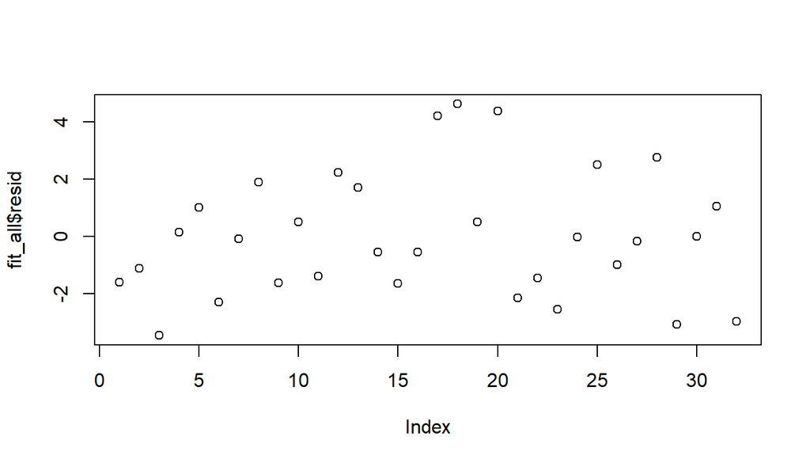

```r
plot(fit_all$resid)
```

Residual plot

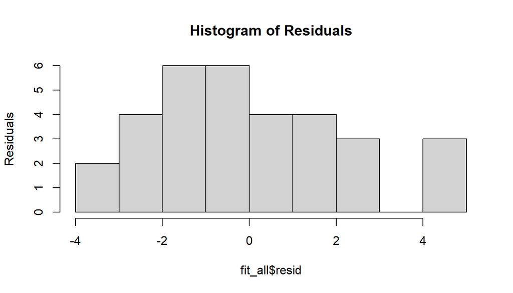

```r
hist(fit_all$resid, main="Histogram of Residuals", ylab="Residuals")
```

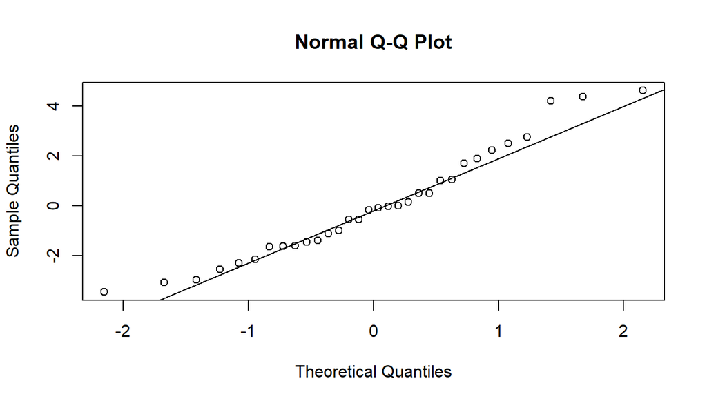

```r
qqnorm(fit_all$resid)
qqline(fit_all$resid)
```